# MATH1324 Assignment 1

Modeling Body Measurements

## Student Details

Jeremy Jian Zhi Chia (s3917515)

## Problem Statement

The purpose of this investigation is to determine if the data on biiliac diameter in men and women fit a normal distribution. The biiliac width refers to the largest measurement of the pelvis between the outside borders of the upper iliac bones in humans, more commonly known as the pelvic bone width. It is hypothesised that the distribution of biiliac diameter among adults regardless of gender are approximate to a measure of central tendency (mean, median or mode). That being said, values near to the mean are rather common, while those further from the mean are less common.

## Load Packages

```r
# Import dependencies
library(readr)
library(dplyr)
library(tidyr)
```

## Data

```r
# Import dataset
bdims <- read_csv("bdims-1.csv")
# View structure of dataset
str(bdims)
```

```
spec_tbl_df [507 x 25] (S3: spec_tbl_df/tbl_df/tbl/data.frame)
 $ bia.di: num [1:507] 42.9 43.7 40.1 44.3 42.5 43.3 43.5 44.4 43.5 42 ...
 $ bii.di: num [1:507] 26 28.5 28.2 29.9 29.9 27 30 29.8 26.5 28 ...
 $ bit.di: num [1:507] 31.5 33.5 33.3 34 34 31.5 34 33.2 32.1 34 ...
 $ che.de: num [1:507] 17.7 16.9 20.9 18.4 21.5 19.6 21.9 21.8 15.5 22.5 ...
 $ che.di: num [1:507] 28 30.8 31.7 28.2 29.4 31.3 31.7 28.8 27.5 28 ...
 $ elb.di:
```

[output not shown]

```
 num [1:507] 13.1 14 13.9 13.9 15.2 14 16.1 15.1 14.1 15.6 ...
 $ wri.di: num [1:507] 10.4 11.8 10.9 11.2 11.6 11.5 12.5 11.9 11.2 12 ...
 $ kne.di: num [1:507] 18.8 20.6 19.7 20.9 20.7 18.8 20.8 21 18.9 21.1 ...
 $ ank.di: num [1:507] 14.1 15.1 14.1 15 14.9 13.9 15.6 14.6 13.2 15 ...
 $ sho.gi: num [1:507] 106 110 115 104 108 ...
 $ che.gi: num [1:507] 89.5 97 97.5 97 97.5 ...
 $ wai.gi: num [1:507] 71.5 79 83.2 77.8 80 82.5 82 76.8 68.5 77.5 ...
 $ nav.gi: num [1:507] 74.5 86.5 82.9 78.8 82.5 80.1 84 80.5 69 81.5 ...
 $ hip.gi: num [1:507] 93.5 94.8 95 94 98.5 95.3 101 98 89.5 99.8 ...
 $ thi.gi: num [1:507] 51.5 51.5 57.3 53 55.4 57.5 60.9 56 50 59.8 ...
 $ bic.gi: num [1:507] 32.5 34.4 33.4 31 32 33 42.4 34.1 33 36.5 ...
 $ for.gi: num [1:507] 26 28 28.8 26.2 28.4 28 32.3 28 26 29.2 ...
 $ kne.gi: num [1:507] 34.5 36.5 37 37 37.7 36.6 40.1 39.2 35.5 38.3 ...
 $ cal.gi: num [1:507] 36.5 37.5 37.3 34.8 38.6 36.1 40.3 36.7 35 38.6 ...
 $ ank.gi: num [1:507] 23.5 24.5 21.9 23 24.4 23.5 23.6 22.5 22 22.2 ...
 $ wri.gi: num [1:507] 16.5 17 16.9 16.6 18 16.9 18.8 18 16.5 16.9 ...
 $ age   : num [1:507] 21 23 28 23 22 21 26 27 23 21 ...
 $ wgt   : num [1:507] 65.6 71.8 80.7 72.6 78.8 74.8 86.4 78.4 62 81.6 ...
 $ hgt   : num [1:507] 174 175 194 186 187 ...
 $ sex   : num [1:507] 1 1 1 1 1 1 1 1 1 1 ...
 - attr(*, "spec")=
  .. cols(
  ..   bia.di = col_double(),
  ..   bii.di = col_double(),
  ..   bit.di = col_double(),
  ..   che.de = col_double(),
  ..   che.di = col_double(),
  ..   elb.di = col_double(),
  ..   wri.di = col_double(),
  ..   kne.di = col_double(),
  ..   ank.di = col_double(),
  ..   sho.gi = col_double(),
  ..   che.gi = col_double(),
  ..   wai.gi = col_double(),
  ..   nav.gi = col_double(),
  ..   hip.gi = col_double(),
  ..   thi.gi = col_double(),
  ..   bic.gi = col_double(),
  ..   for.gi = col_double(),
  ..   kne.gi = col_double(),
  ..   cal.gi = col_double(),
  ..   ank.gi = col_double(),
  ..   wri.gi = col_double(),
  ..   age = col_double(),
  ..   wgt = col_double(),
  ..   hgt = col_double(),
  ..   sex = col_double()
  .. )
 - attr(*, "problems")=<externalptr>
```

```r
# Set gender as factor
bdims$sex <- factor(bdims$sex, levels = c(0, 1), labels = c("female", "male"))

# Check attributes of gender factor
attributes(bdims$sex)
```

```
$levels
[1] "female" "male"

$class
[1] "factor"
```

```r
# Selecting only variables of interest from entire dataset
biiliac_gender <- bdims %>% dplyr::select(bii.di, sex)

# View selected variables
biiliac_gender %>% head()
```

| bii.di | sex |
| --- | --- |
| 26.0 | male |
| 28.5 | male |
| 28.2 | male |
| 29.9 | male |
| 29.9 | male |
| 27.0 | male |

## Summary Statistics

Calculate descriptive statistics (i.e., mean, median, standard deviation, first and third quartile, interquartile range, minimum and maximum values) of the selected measurement grouped by sex.

```r
# Create new variables and filter by gender
biiliac_male <- biiliac_gender %>% filter(sex == "male")
biiliac_female <- biiliac_gender %>% filter(sex == "female")
```

```r
# Mean of male biiliac width
male_mean <- biiliac_male$bii.di %>% mean()
male_mean
```

```
[1] 28.0915
```

```r
# Mean of female biiliac width
female_mean <- biiliac_female$bii.di %>% mean()
female_mean
```

```
[1] 27.58154
```

```r
# Median of male biiliac width
male_median <- biiliac_male$bii.di %>% median()
male_median
```

```
[1] 28
```

```r
# Median of female biiliac width
female_median <- biiliac_female$bii.di %>% median()
female_median
```

```
[1] 27.8
```

```r
# SD of male biiliac width
male_sd <- biiliac_male$bii.di %>% sd()
male_sd
```

```
[1] 2.067098
```

```r
# SD of female biiliac width
female_sd <- biiliac_female$bii.di %>% sd()
female_sd
```

```
[1] 2.307476
```

```r
# Quartiles of male biiliac width
male_quantile <- biiliac_male$bii.di %>% quantile()
male_quantile
```

```
   0%   25%   50%   75%  100%
19.40 26.80 28.00 29.45 34.70
```

The first quartile for males biiliac width is 26.8 and the third quartile is 29.45.

```r
# Quartiles of male biiliac width
female_quantile <- biiliac_female$bii.di %>% quantile()
female_quantile
```

```
  0%  25%  50%  75% 100%
18.7 26.2 27.8 29.2 33.3
```

The first quartile for females biiliac width is 26.2 and the third quartile is 29.2.

```r
# IQR of male biiliac width
male_iqr <- biiliac_male$bii.di %>% IQR()
male_iqr
```

```
[1] 2.65
```

```r
# IQR of female biiliac width
female_iqr <- biiliac_female$bii.di %>% IQR()
female_iqr
```

```
[1] 3
```

```r
# Min/Max of male biiliac width
male_range <- biiliac_male$bii.di %>% range()
male_range
```

```
[1] 19.4 34.7
```

```r
# Min/Max of male biiliac width
female_range <- biiliac_female$bii.di %>% range()
female_range
```

```
[1] 18.7 33.3
```

## Distribution Fitting

Comparing the empirical distribution of selected body measurement to a normal distribution separately in men and in women. This is done visually by plotting the histogram with normal distribution overlay.

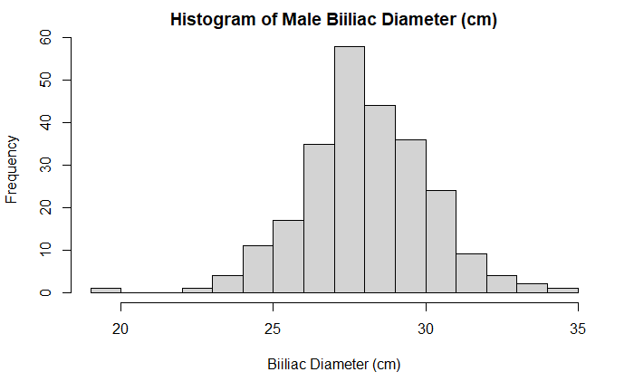

```r
# Plotting histogram of male biiliac diameter frequencies
hist(biiliac_male$bii.di, freq = TRUE, breaks = 12, xlab = "Biiliac Diameter (cm)", main = "Histogram of Male Biiliac Diameter (cm)")
```

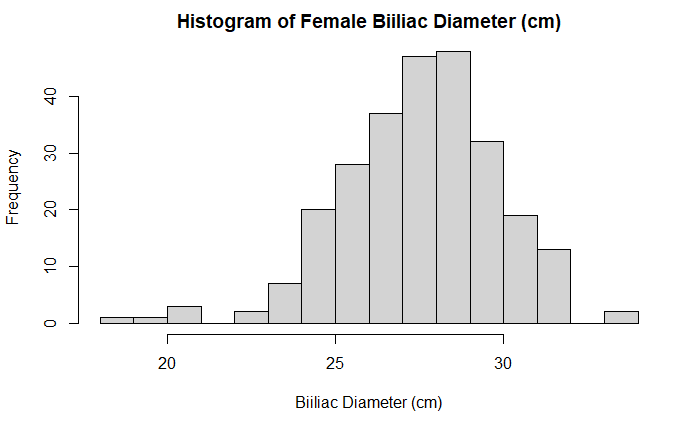

```r
# Plotting histogram of female biiliac diameter frequencies
hist(biiliac_female$bii.di, freq = TRUE, breaks = 12, xlab = "Biiliac Diameter (cm)", main = "Histogram of Female Biiliac Diameter (cm)")
```

```r
# Plotting distribution for males billiac width using probability density
hist(biiliac_male$bii.di, freq = FALSE, breaks = 12, xlab = "Biiliac Diameter (cm)", main = "Histogram of Male Biiliac Diameter (cm)")

# Adding empirical density line
lines(density(biiliac_male$bii.di), col = "red")
```

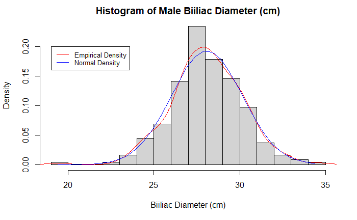

```r
# Adding normal density line
lines(seq(male_range[1], male_range[2], by=.5), dnorm(seq(male_range[1], male_range[2], by=.5),
      male_mean, male_sd), col="blue")

# Adding legends
legend(19, 0.20, legend=c("Empirical Density", "Normal Density"), col=c("red", "blue"), lty=1:1, cex=0.8)
```

```r
# Plotting distribution for female billiac width using probability density
hist(biiliac_female$bii.di, freq = FALSE, breaks = 12, xlab = "Biiliac Diameter (cm)", main = "Histogram of Female Biiliac Diameter (cm)")

# Adding empirical density line
lines(density(biiliac_female$bii.di), col = "red")
```

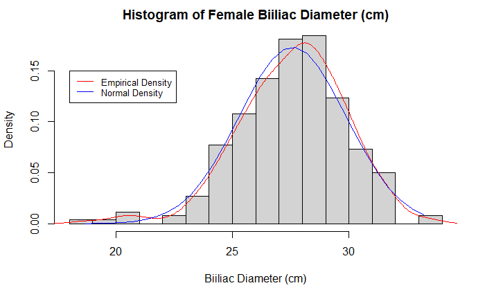

```r
# Adding normal density line
lines(seq(female_range[1], female_range[2], by=.5), dnorm(seq(female_range[1], female_range[2], by=.5),
      female_mean, female_sd), col="blue")

# Adding legends
legend(18, 0.15, legend=c("Empirical Density", "Normal Density"), col=c("red", "blue"), lty=1:1, cex=0.8)
```

The above two histograms show the density distribution of both male and female respondents’ biiliac diameters. The plots each have overlays for the empirical and normal density. The empirical density curve shows how the empirical data is distributed as compared to the normal distribution curve.

## Interpretation

The purpose of this investigation was to find out if the biiliac diameter in men and women fit a normal distribution.

Based on the histogram of female biiliac diameter, the histogram also appears to resemble a bell shaped curve with more of a left skew than the males biiliac diameter histogram. Both the empirical density and normal density curves are slightly apart but still generally sit closely with each other. There is also an indication here that the theoretical normal distribution fits the empirical data. However, for the case of the female respondents, there seems to be a higher number of potential outliers as compared to the male respondents. Despite the higher number of potential outliers, these outliers are still considered insignificant in frequency/density as compared to the rest of the data. Therefore, the female biiliac diameter fits a normal distribution.